# Israel & Palistine Conflict Prediction

[figure not shown]

The dataset captures fluctuations in conflict intensity, with counts of fatalities aggregated on a monthly basis. This granularity enables an in-depth analysis of trends, patterns, and potential seasonal or cyclical variations in the violence.

Through exploratory analysis, we have observed periods with heightened conflict, reflected in increased fatalities. These peaks may correlate with significant political events, military operations, or escalations in hostilities. Conversely, troughs in the data may indicate times of relative calm or successful peacekeeping efforts.

Utilizing various analytical techniques, from statistical analysis to predictive modeling, the dataset serves not only as a historical record but also as a means to forecast future trends. Advanced methods like SARIMA modeling and machine learning have been applied to understand the underlying structures and to make educated predictions about future conflict dynamics.

The insights derived from this dataset are invaluable for policymakers, researchers, and peace organizations striving to comprehend the conflict's complexity and work towards its resolution.

By: John Chilton

# Loading necessary libraries

```python
!pip install simplekml
```

```python
import numpy as np
import pandas as pd
import seaborn as sns
import matplotlib.pyplot as plt
%matplotlib inline
sns.set_style("whitegrid")
from sklearn.model_selection import train_test_split
from sklearn.ensemble import RandomForestRegressor
from sklearn.metrics import mean_squared_error
from statsmodels.tsa.stattools import acf, pacf
from statsmodels.graphics.tsaplots import plot_acf, plot_pacf
from statsmodels.tsa.statespace.sarimax import SARIMAX
from sklearn.metrics import mean_squared_error
from sklearn.cluster import KMeans
from sklearn.preprocessing import StandardScaler
from sklearn.metrics import silhouette_score
import plotly.express as px
```

# Loading The Dataset

```python
from google.colab import drive
drive.mount('/content/drive')
```

```python
df = pd.read_csv('/content/drive/MyDrive/lab_mount/fatalities_isr_pse_conflict_2000_to_2023.csv')
```

# Data Overview

- Oberservations
- Sanity Checks

```python
df.head(10)
```

|  | name | date_of_event | age | citizenship | event_location | event_location_district | event_location_region | date_of_death | gender | took_part_in_the_hostilities | place_of_residence | place_of_residence_district | type_of_injury | ammunition | killed_by | notes |
| --- | --- | --- | --- | --- | --- | --- | --- | --- | --- | --- | --- | --- | --- | --- | --- | --- |
| 0 | 'Abd a-Rahman Suleiman Muhammad Abu Daghash | 2023-09-24 | 32.0 | Palestinian | Nur Shams R.C. | Tulkarm | West Bank | 2023-09-24 | M | NaN | Nur Shams R.C. | Tulkarm | gunfire | live ammunition | Israeli security forces | Fatally shot by Israeli forces while standing ... |
| 1 | Usayed Farhan Muhammad 'Ali Abu 'Ali | 2023-09-24 | 21.0 | Palestinian | Nur Shams R.C. | Tulkarm | West Bank | 2023-09-24 | M | NaN | Nur Shams R.C. | Tulkarm | gunfire | live ammunition | Israeli security forces | Fatally shot by Israeli forces while trying to... |
| 2 | 'Abdallah 'Imad Sa'ed Abu Hassan | 2023-09-22 | 16.0 | Palestinian | Kfar Dan | Jenin | West Bank | 2023-09-22 | M | NaN | al-Yamun | Jenin | gunfire | live ammunition | Israeli security forces | Fatally shot by soldiers while firing at them ... |
| 3 | Durgham Muhammad Yihya al-Akhras | 2023-09-20 | 19.0 | Palestinian | 'Aqbat Jaber R.C. | Jericho | West Bank | 2023-09-20 | M | NaN | 'Aqbat Jaber R.C. | Jericho | gunfire | live ammunition | Israeli security forces | Shot in the head by Israeli forces while throw... |
| 4 | Raafat 'Omar Ahmad Khamaisah | 2023-09-19 | 15.0 | Palestinian | Jenin R.C. | Jenin | West Bank | 2023-09-19 | M | NaN | Jenin | Jenin | gunfire | live ammunition | Israeli security forces | Wounded by soldiers’ gunfire after running awa... |
| 5 | 'Ata Yasser 'Ata Musa | 2023-09-19 | 29.0 | Palestinian | Jenin R.C. | Jenin | West Bank | 2023-09-20 | M | NaN | Jenin | Jenin | gunfire | missile | Israeli security forces | Wounded by shrapnel from a missile fired by Is... |
| 6 | Yusef Salem Yusef Radwan | 2023-09-19 | 24.0 | Palestinian | Gaza City | Gaza | Gaza Strip | 2023-09-19 | M | No | Khan Yunis | Khan Yunis | gunfire | live ammunition | Israeli security forces | Fatally shot by soldiers while participating i... |
| 7 | Mahmoud Khaled S'ud 'Ar'arawi | 2023-09-19 | 25.0 | Palestinian | Jenin R.C. | Jenin | West Bank | 2023-09-19 | M | NaN | Jenin R.C. | Jenin | gunfire | missile | Israeli security forces | Wounded by shrapnel from a missile fired by Is... |
| 8 | Mahmoud 'Ali Nafe'a a-S'adi | 2023-09-19 | 23.0 | Palestinian | Jenin R.C. | Jenin | West Bank | 2023-09-19 | M | NaN | Jenin R.C. | Jenin | gunfire | missile | Israeli security forces | Wounded by shrapnel from a missile fired by Is... |
| 9 | Milad Munzer Wajih a-Ra'i | 2023-09-09 | 15.0 | Palestinian | al-'Arrub R.C. | Hebron | West Bank | 2023-09-09 | M | NaN | al-'Arrub Camp | Hebron | gunfire | live ammunition | Israeli security forces | Fatally shot by a soldier after throwing two M... |

```python
df.tail(10)
```

|  | name | date_of_event | age | citizenship | event_location | event_location_district | event_location_region | date_of_death | gender | took_part_in_the_hostilities | place_of_residence | place_of_residence_district | type_of_injury | ammunition | killed_by | notes |
| --- | --- | --- | --- | --- | --- | --- | --- | --- | --- | --- | --- | --- | --- | --- | --- | --- |
| 11114 | Ayelet Shahar Levy | 2000-11-02 | 28.0 | Israeli | Jerusalem | Israel | Israel | 2000-11-02 | F | Israelis | Ma'ale Mikhmas | Ramallah and al-Bira | explosion | car bomb | Palestinian civilians | Killed by a booby-trapped car near the Lev Had... |
| 11115 | Hanan Levy | 2000-11-02 | 33.0 | Israeli | Jerusalem | Israel | Israel | 2000-11-02 | M | Israelis | Jerusalem | Israel | explosion | car bomb | Palestinian civilians | killed in a booby-trapped car near the Mahane ... |
| 11116 | Eish Kodesh Gilmor | 2000-10-30 | 25.0 | Israeli | East Jerusalem | East Jerusalem | West Bank | 2000-10-30 | M | Israelis | Mevo Modi'im | Israel | gunfire | live ammunition | Palestinian civilians | Killed while he was guarding a National Insura... |
| 11117 | Amos Machlouf | 2000-10-28 | 30.0 | Israeli | Beit Jala | Bethlehem | West Bank | 2000-10-28 | M | Israelis | East Jerusalem | East Jerusalem | stabbing | NaN | Palestinian civilians | Killed when he was stabbed and shot. His body ... |
| 11118 | Marik Gavrilov | 2000-10-27 | 25.0 | Israeli | Ramallah | Ramallah and al-Bira | West Bank | 2000-10-27 | M | Israelis | Banei Ayish | Israel | gunfire | live ammunition | Palestinian civilians | His body was found burnt in his car. |
| 11119 | Binyamin Herling | 2000-10-19 | 64.0 | Israeli | Nablus | Nablus | West Bank | 2000-10-19 | M | Israelis | Kedumim | Tulkarm | gunfire | live ammunition | Palestinian civilians | Killed while hiking on Mt. Eival. |
| 11120 | Farid Musa 'Issa a-Nesasreh | 2000-10-17 | 28.0 | Palestinian | Beit Furik | Nablus | West Bank | 2000-10-17 | M | Unknown | Beit Furik | Nablus | gunfire | NaN | Israeli civilians | Killed by a settler from Itamar while harvesti... |
| 11121 | Hillel Lieberman | 2000-10-07 | 36.0 | Israeli | Nablus | Nablus | West Bank | 2000-10-07 | M | Israelis | Elon Moreh | Nablus | gunfire | live ammunition | Palestinian civilians | His body was found a day after he disappeared. |
| 11122 | Fahed Mustafa 'Odeh Baker | 2000-10-07 | 21.0 | Palestinian | Bidya | Salfit | West Bank | 2000-10-07 | M | No | Bidya | Salfit | gunfire | NaN | Israeli civilians | Killed by settlers who rioted in Biddya village. |
| 11123 | Wichlav Zalsevsky | 2000-10-02 | 24.0 | Israeli | Masha | Salfit | West Bank | 2000-10-02 | M | Israelis | Ashdod | Israel | gunfire | live ammunition | Palestinian civilians | NaN |

```python
df.shape
```

```
(11124, 16)
```

```python
df.info()
```

```
<class 'pandas.core.frame.DataFrame'>
RangeIndex: 11124 entries, 0 to 11123
Data columns (total 16 columns):
 #   Column                        Non-Null Count  Dtype
---  ------                        --------------  -----
 0   name                          11124 non-null  object
 1   date_of_event                 11124 non-null  object
 2   age                           10995 non-null  float64
 3   citizenship                   11124 non-null  object
 4   event_location                11124 non-null  object
 5   event_location_district       11124 non-null  object
 6   event_location_region         11124 non-null  object
 7   date_of_death                 11124 non-null  object
 8   gender                        11104 non-null  object
 9   took_part_in_the_hostilities  9694 non-null   object
 10  place_of_residence            11056 non-null  object
 11  place_of_residence_district   11056 non-null  object
 12  type_of_injury                10833 non-null  object
 13  ammunition                    5871 non-null   object
 14  killed_by                     11124 non-null  object
 15  notes                         10844 non-null  object
dtypes: float64(1), object(15)
memory usage: 1.4+ MB
```

```python
df.describe().T
```

|  | count | mean | std | min | 25% | 50% | 75% | max |
| --- | --- | --- | --- | --- | --- | --- | --- | --- |
| age | 10995.0 | 26.745703 | 13.780548 | 1.0 | 19.0 | 23.0 | 31.0 | 112.0 |

```python
df.isnull().sum()
```

```
name                               0
date_of_event                      0
age                              129
citizenship                        0
event_location                     0
event_location_district            0
event_location_region              0
date_of_death                      0
gender                            20
took_part_in_the_hostilities    1430
place_of_residence                68
place_of_residence_district       68
type_of_injury                   291
ammunition                      5253
killed_by                          0
notes                            280
dtype: int64
```

```python
df.duplicated().sum()
```

```
7
```

```python
df.mean()
```

```
age    26.745703
dtype: float64
```

```python
df.mode()
```

|  | name | date_of_event | age | citizenship | event_location | event_location_district | event_location_region | date_of_death | gender | took_part_in_the_hostilities | place_of_residence | place_of_residence_district | type_of_injury | ammunition | killed_by | notes |
| --- | --- | --- | --- | --- | --- | --- | --- | --- | --- | --- | --- | --- | --- | --- | --- | --- |
| 0 | Name unknown to B'Tselem | 2008-12-27 | 22.0 | Palestinian | Gaza City | Gaza | Gaza Strip | 2008-12-27 | M | No | Gaza city | Gaza | gunfire | missile | Israeli security forces | Killed during "Operation Defensive Shield." |

```python
df.std()
```

```
age    13.780548
dtype: float64
```

```python
# Check for missing values in the dataset
missing_values = df.isnull().sum()

# Convert 'date_of_event' to datetime for further time series analysis
df['date_of_event'] = pd.to_datetime(df['date_of_event'])

# Extract year, month, and day from 'date_of_event' for potential feature use
df['year'] = df['date_of_event'].dt.year
df['month'] = df['date_of_event'].dt.month
df['day'] = df['date_of_event'].dt.day
df['day_of_week'] = df['date_of_event'].dt.dayofweek  # Monday=0, Sunday=6

# Encoding categorical data
# For simplicity, we'll convert categorical variables to category types and encode them as integers
categorical_columns = ['citizenship', 'event_location_district', 'event_location_region', 'gender', 'type_of_injury', 'ammunition', 'killed_by']
for col in categorical_columns:
    df[col] = df[col].astype('category')
    df[col + '_code'] = df[col].cat.codes

# Check the dataframe after preprocessing
preprocessed_head = df.head()
missing_values, preprocessed_head
```

```
(name                               0
 date_of_event                      0
 age                              129
 citizenship                        0
 event_location                     0
 event_location_district            0
 event_location_region              0
 date_of_death                      0
 gender                            20
 took_part_in_the_hostilities    1430
 place_of_residence                68
 place_of_residence_district       68
 type_of_injury                   291
 ammunition                      5253
 killed_by                          0
 notes                            280
 dtype: int64,
                                           name date_of_event   age  \
 0  'Abd a-Rahman Suleiman Muhammad Abu Daghash    2023-09-24  32.0
 1         Usayed Farhan Muhammad 'Ali Abu 'Ali    2023-09-24  21.0
 2             'Abdallah 'Imad Sa'ed Abu Hassan    2023-09-22  16.0
 3             Durgham Muhammad Yihya al-Akhras    2023-09-20  19.0
 4                 Raafat 'Omar Ahmad Khamaisah    2023-09-19  15.0

    citizenship     event_location event_location_district  \
 0  Palestinian     Nur Shams R.C.                 Tulkarm
 1  Palestinian     Nur Shams R.C.                 Tulkarm
 2  Palestinian           Kfar Dan                   Jenin
 3  Palestinian  'Aqbat Jaber R.C.                 Jericho
 4  Palestinian         Jenin R.C.                   Jenin

   event_location_region date_of_death gender took_part_in_the_hostilities  \
 0             West Bank    2023-09-24      M                          NaN
 1             West Bank    2023-09-24      M                          NaN
 2             West Bank    2023-09-22      M                          NaN
 3             West Bank    2023-09-20      M                          NaN
 4             West Bank    2023-09-19      M                          NaN

    ... month day day_of_week citizenship_code event_location_district_code  \
 0  ...     9  24           6                3                           18
 1  ...     9  24           6                3                           18
 2  ...     9  22           4                3                            8
 3  ...     9  20           2                3                            9
 4  ...     9  19           1                3                            8

   event_location_region_code  gender_code  type_of_injury_code  \
 0                          2            1                    5
 1                          2            1                    5
 2                          2            1                    5
 3                          2            1                    5
 4                          2            1                    5

    ammunition_code  killed_by_code
 0               10               1
 1               10               1
 2               10               1
 3               10               1
 4               10               1

 [5 rows x 27 columns])
```

```python
# Handling missing values for 'age' with the median
df['age'].fillna(df['age'].median(), inplace=True)

# Handling missing values for 'gender' with the mode
df['gender'].fillna(df['gender'].mode()[0], inplace=True)
df['gender_code'] = df['gender'].cat.codes  # Update the codes after filling missing values

# For 'type_of_injury' and 'ammunition', we create an 'Unknown' category for missing values
df['type_of_injury'].cat.add_categories('Unknown', inplace=True)
df['type_of_injury'].fillna('Unknown', inplace=True)
df['type_of_injury_code'] = df['type_of_injury'].cat.codes  # Update the codes

df['ammunition'].cat.add_categories('Unknown', inplace=True)
df['ammunition'].fillna('Unknown', inplace=True)
df['ammunition_code'] = df['ammunition'].cat.codes  # Update the codes

# Drop 'took_part_in_the_hostilities' column as it has a large number of missing values and unclear how to handle
df.drop('took_part_in_the_hostilities', axis=1, inplace=True)

# Check the updated dataframe for missing values
updated_missing_values = df.isnull().sum()
updated_missing_values
```

```
name                              0
date_of_event                     0
age                               0
citizenship                       0
event_location                    0
event_location_district           0
event_location_region             0
date_of_death                     0
gender                            0
place_of_residence               68
place_of_residence_district      68
type_of_injury                    0
ammunition                        0
killed_by                         0
notes                           280
year                              0
month                             0
day                               0
day_of_week                       0
citizenship_code                  0
event_location_district_code      0
event_location_region_code        0
gender_code                       0
type_of_injury_code               0
ammunition_code                   0
killed_by_code                    0
dtype: int64
```

# Exploratory Data Analysis (EDA)

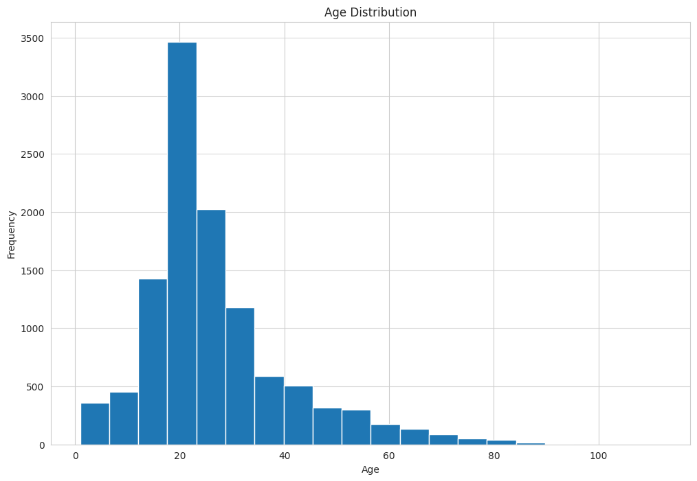

```python
# Plot histogram for the 'age' column with a larger figure size
plt.figure(figsize=(12, 8))  # Increase the figure size
df['age'].plot(kind='hist', bins=20, title='Age Distribution')
plt.xlabel('Age')
plt.ylabel('Frequency')
plt.grid(axis='y', alpha=0.75)
plt.show()
```

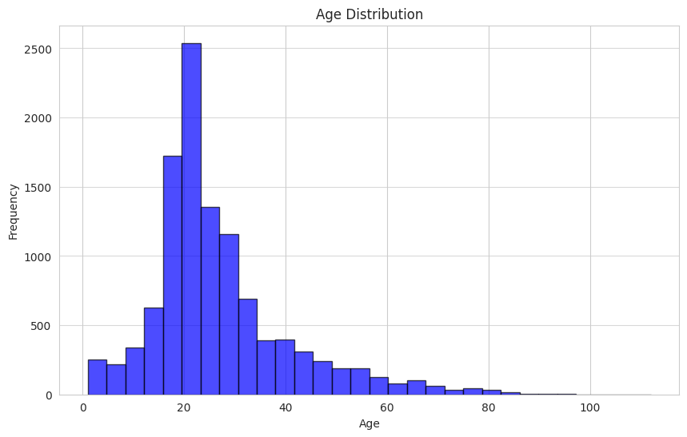

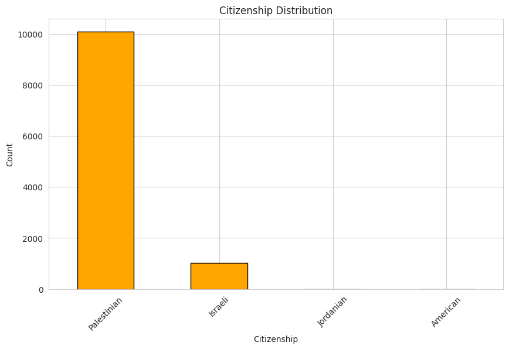

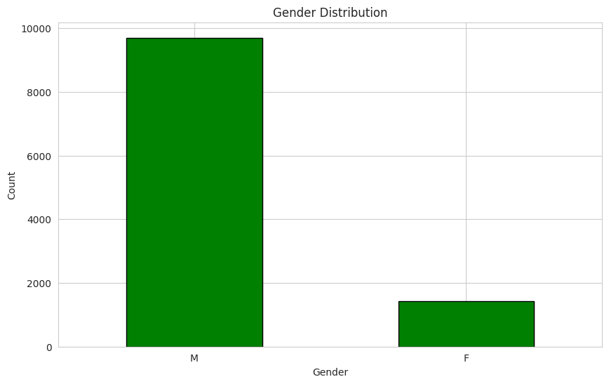

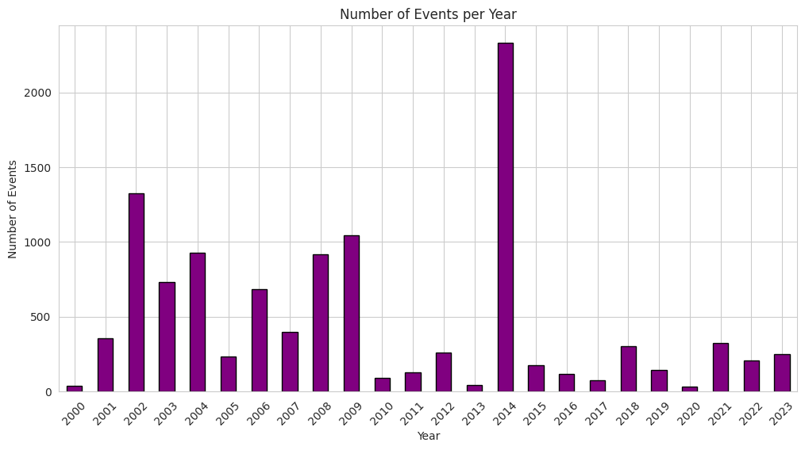

```python
# Plotting the distribution of age
plt.figure(figsize=(10, 6))
plt.hist(df['age'], bins=30, color='blue', edgecolor='black', alpha=0.7)
plt.title('Age Distribution')
plt.xlabel('Age')
plt.ylabel('Frequency')
plt.grid(axis='y', alpha=0.75)
plt.show()

# Plotting the distribution of citizenship
plt.figure(figsize=(10, 6))
df['citizenship'].value_counts().plot(kind='bar', color='orange', edgecolor='black')
plt.title('Citizenship Distribution')
plt.xlabel('Citizenship')
plt.ylabel('Count')
plt.xticks(rotation=45)
plt.show()

# Plotting the distribution of gender
plt.figure(figsize=(10, 6))
df['gender'].value_counts().plot(kind='bar', color='green', edgecolor='black')
plt.title('Gender Distribution')
plt.xlabel('Gender')
plt.ylabel('Count')
plt.xticks(rotation=0)
plt.show()

# Plotting the number of events per year
plt.figure(figsize=(12, 6))
df['year'].value_counts().sort_index().plot(kind='bar', color='purple', edgecolor='black')
plt.title('Number of Events per Year')
plt.xlabel('Year')
plt.ylabel('Number of Events')
plt.xticks(rotation=45)
plt.show()
```

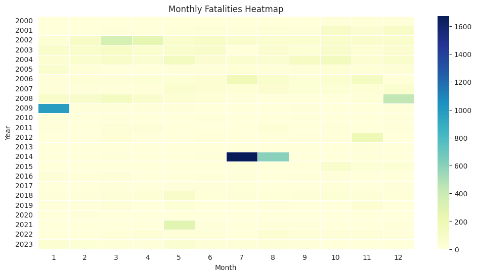

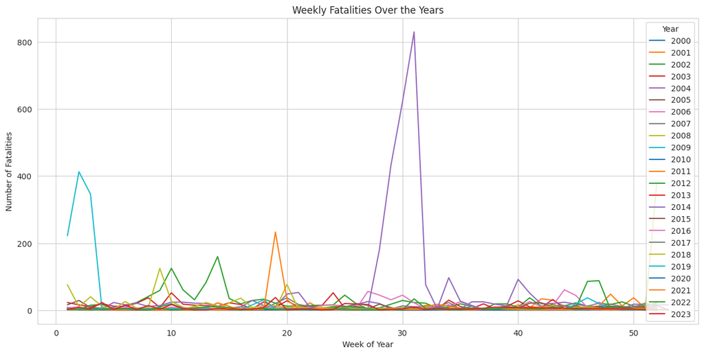

```python
# Monthly pattern analysis
monthly_counts = df.groupby([df['date_of_event'].dt.year, df['date_of_event'].dt.month]).size().unstack(fill_value=0)
plt.figure(figsize=(12, 6))
sns.heatmap(monthly_counts, cmap="YlGnBu", linewidths=.5)
plt.title('Monthly Fatalities Heatmap')
plt.xlabel('Month')
plt.ylabel('Year')
plt.show()

# Weekly pattern analysis
# Adding a 'week_of_year' column to the dataframe
df['week_of_year'] = df['date_of_event'].dt.isocalendar().week
weekly_counts = df.groupby(['year', 'week_of_year']).size().reset_index(name='counts')

# Plotting weekly patterns over the years
plt.figure(figsize=(15, 7))
for year in weekly_counts['year'].unique():
    weekly_data = weekly_counts[weekly_counts['year'] == year]
    plt.plot(weekly_data['week_of_year'], weekly_data['counts'], label=year)

plt.title('Weekly Fatalities Over the Years')
plt.xlabel('Week of Year')
plt.ylabel('Number of Fatalities')
plt.legend(title='Year')
plt.show()
```

# Build The Model

```python
# Aggregating the data to monthly fatalities
monthly_fatalities = df.resample('M', on='date_of_event').size()

# Resetting the index to have consecutive integers
monthly_fatalities = monthly_fatalities.reset_index(drop=False)

# Creating features from the date
monthly_fatalities['year'] = monthly_fatalities['date_of_event'].dt.year
monthly_fatalities['month'] = monthly_fatalities['date_of_event'].dt.month

# The target variable is the count of fatalities
X = monthly_fatalities[['year', 'month']]
y = monthly_fatalities[0]

# Splitting the dataset into training and testing sets
X_train, X_test, y_train, y_test = train_test_split(X, y, test_size=0.2, random_state=42, shuffle=False)

# Initialize the Random Forest Regressor
rf = RandomForestRegressor(n_estimators=100, random_state=42)

# Train the model
rf.fit(X_train, y_train)

# Predict on the test set
y_pred = rf.predict(X_test)

# Calculate the mean squared error
mse = mean_squared_error(y_test, y_pred)
rmse = mse ** 0.5

rmse
```

```
37.50264021658056
```

```python
# Adding lagged features for the number of events
monthly_fatalities['lag_1'] = monthly_fatalities[0].shift(1)  # Last month's fatalities
monthly_fatalities['lag_2'] = monthly_fatalities[0].shift(2)  # Fatalities from two months ago

# Adding a rolling window feature (rolling mean over the last 3 months)
monthly_fatalities['rolling_mean_3'] = monthly_fatalities[0].rolling(window=3).mean()

# Dropping the initial rows where the lagged features are NaN
monthly_fatalities.dropna(inplace=True)

# Redefine X and y with new features
X = monthly_fatalities[['year', 'month', 'lag_1', 'lag_2', 'rolling_mean_3']]
y = monthly_fatalities[0]

# Splitting the dataset into training and testing sets again
X_train, X_test, y_train, y_test = train_test_split(X, y, test_size=0.2, random_state=42, shuffle=False)

# Initialize a new Random Forest Regressor
rf = RandomForestRegressor(n_estimators=100, random_state=42)

# Train the model with new features
rf.fit(X_train, y_train)

# Predict on the test set with new features
y_pred = rf.predict(X_test)

# Calculate the mean squared error with new features
mse = mean_squared_error(y_test, y_pred)
rmse = mse ** 0.5

rmse
```

```
29.308643528054066
```

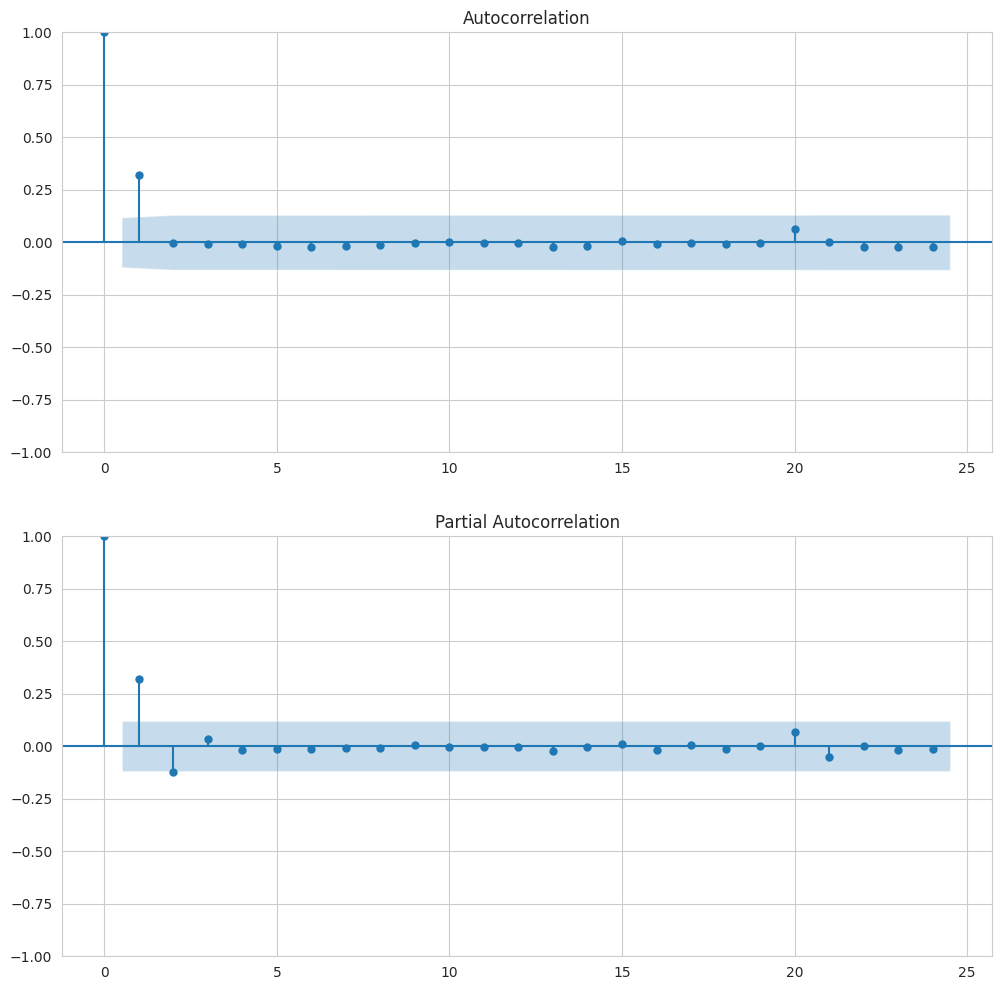

```python
# We will use the original monthly_fatalities series for this (without the lag and rolling features)
# Let's first drop the additional features we added for the Random Forest model
monthly_fatalities_sarima = monthly_fatalities[['date_of_event', 0]].set_index('date_of_event')

# Plot the ACF and PACF
fig, (ax1, ax2) = plt.subplots(2, 1, figsize=(12, 12))

# Plot the ACF on ax1
plot_acf(monthly_fatalities_sarima[0], lags=24, ax=ax1)

# Plot the PACF on ax2
plot_pacf(monthly_fatalities_sarima[0], lags=24, ax=ax2)

plt.show()
```

```python
# Defining a function to fit SARIMA model and calculate RMSE
def fit_sarima(train, order, seasonal_order):
    model = SARIMAX(train, order=order, seasonal_order=seasonal_order)
    model_fit = model.fit(disp=False)
    return model_fit

# Split the data into train and test sets
train = monthly_fatalities_sarima.iloc[:-12, 0]  # leave last 12 months for testing
test = monthly_fatalities_sarima.iloc[-12:, 0]   # test set

# Initial guesses for SARIMA parameters
# p: The number of lag observations included in the model (lag order).
# d: The number of times that the raw observations are differenced (degree of differencing).
# q: The size of the moving average window (order of moving average).
p = 1  # Just an initial guess, should be refined
d = 1  # We might need differencing since the data is likely non-stationary
q = 1  # Just an initial guess, should be refined
P = 1  # Seasonal AR term
D = 1  # Seasonal differencing
Q = 1  # Seasonal MA term
s = 12 # Monthly data so seasonal period is 12

# Fit the model
sarima_model = fit_sarima(train, (p, d, q), (P, D, Q, s))

# Make predictions
predictions = sarima_model.get_forecast(steps=12)
predicted_means = predictions.predicted_mean

# Calculate RMSE
rmse_sarima = mean_squared_error(test, predicted_means, squared=False)
rmse_sarima
```

```
24.447606461457045
```

```python
# Fit the model with the best parameters found
best_sarima_model = SARIMAX(train,
                            order=best_pdq,
                            seasonal_order=best_seasonal_pdq,
                            enforce_stationarity=False,
                            enforce_invertibility=False).fit(disp=False)

# Forecast the next 12 months and calculate the RMSE
forecast = best_sarima_model.get_forecast(steps=12)
forecast_mean = forecast.predicted_mean
rmse_best_sarima = mean_squared_error(test, forecast_mean, squared=False)

# Display the RMSE
rmse_best_sarima
```

[output not shown]

[output not shown]

```
27.95990252582149
```

```python
# Redefine the cross-validation function with a correct expanding window approach
def ts_cross_val_score(data, pdq, seasonal_pdq, initial_train_size, horizon, step):
    """
    Perform time series cross-validation with an expanding window approach
    :param data: time series data
    :param pdq: ARIMA parameters
    :param seasonal_pdq: Seasonal ARIMA parameters
    :param initial_train_size: initial size of training data
    :param horizon: prediction horizon
    :param step: number of steps to move the window each time
    :return: list of RMSE scores for each fold
    """
    tscv_rmse = []
    n_samples = len(data)

    # Start after the initial training size
    for start in range(initial_train_size, n_samples, step):
        end = start + horizon
        if end > n_samples:
            break  # if we don't have enough data left for the horizon, we are done

        train_data = data[:start]
        test_data = data[start:end]

        # Fit the model
        model = SARIMAX(train_data, order=pdq, seasonal_order=seasonal_pdq, enforce_stationarity=False, enforce_invertibility=False)
        model_fit = model.fit(disp=False)

        # Forecast
        forecast = model_fit.get_forecast(steps=horizon)
        forecast_mean = forecast.predicted_mean

        # Calculate and store the RMSE for this fold
        rmse = mean_squared_error(test_data, forecast_mean, squared=False)
        tscv_rmse.append(rmse)

    return tscv_rmse

# Set the initial training size, horizon, and step for the expanding window
initial_train_size = len(train) - (2 * 12)  # initial training size to leave out two years for testing
horizon = 12  # one year prediction horizon
step = 6  # step size of 6 months

# Perform cross-validation and calculate average RMSE
cv_rmse_scores = ts_cross_val_score(monthly_fatalities_sarima[0], best_pdq, best_seasonal_pdq, initial_train_size, horizon, step)
avg_cv_rmse = sum(cv_rmse_scores) / len(cv_rmse_scores)

avg_cv_rmse, cv_rmse_scores
```

```
(53.87661701357342,
 [84.21743718633005,
  82.7361198383446,
  40.919516600983975,
  33.550108916386996,
  27.95990252582149])
```

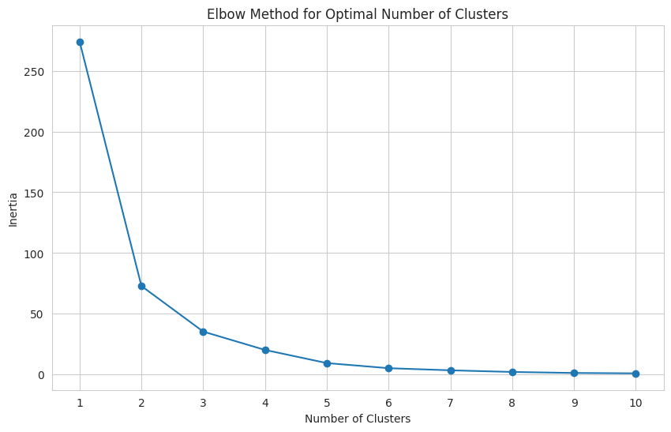

```python
# For clustering, we'll consider the monthly fatalities as one of the features.
# If we had more features, we could include them as well.
# Let's prepare the data for clustering
features_for_clustering = monthly_fatalities[[0]]  # Feature 0 is the number of fatalities

# Standardize the features
scaler = StandardScaler()
scaled_features = scaler.fit_transform(features_for_clustering)

# Determine the optimal number of clusters using the Elbow Method
# We will consider 1 to 10 clusters
inertia = []
for n_clusters in range(1, 11):
    kmeans = KMeans(n_clusters=n_clusters, random_state=42)
    kmeans.fit(scaled_features)
    inertia.append(kmeans.inertia_)

# Plot the inertia to see where the "elbow" is
plt.figure(figsize=(10, 6))
plt.plot(range(1, 11), inertia, marker='o')
plt.title('Elbow Method for Optimal Number of Clusters')
plt.xlabel('Number of Clusters')
plt.ylabel('Inertia')
plt.xticks(range(1, 11))
plt.show()
```

```python
# Since we cannot visually inspect the elbow plot, we'll programmatically choose an 'elbow'
# using a simple heuristic: the point where the inertia decrease rate diminishes

# Calculate the decrease rate of inertia
inertia_decrease_rate = np.diff(inertia)

# Find the elbow point which is the first point with a decrease rate lower than the mean decrease rate
elbow_point = np.where(inertia_decrease_rate < np.mean(inertia_decrease_rate))[0][0] + 1  # adding 1 because np.diff reduces the length by 1

# Now run KMeans with the optimal number of clusters found
optimal_clusters = elbow_point
kmeans = KMeans(n_clusters=optimal_clusters, random_state=42)
clusters = kmeans.fit_predict(scaled_features)

# Add the cluster labels to our data
monthly_fatalities['cluster'] = clusters

# Check the first few rows to confirm clustering labels have been added
monthly_fatalities.head()
```

|  | date_of_event | 0 | year | month | lag_1 | lag_2 | rolling_mean_3 | cluster |
| --- | --- | --- | --- | --- | --- | --- | --- | --- |
| 2 | 2000-12-31 | 10 | 2000 | 12 | 17.0 | 8.0 | 11.666667 | 0 |
| 3 | 2001-01-31 | 6 | 2001 | 1 | 10.0 | 17.0 | 11.000000 | 0 |
| 4 | 2001-02-28 | 5 | 2001 | 2 | 6.0 | 10.0 | 7.000000 | 0 |
| 5 | 2001-03-31 | 8 | 2001 | 3 | 5.0 | 6.0 | 6.333333 | 0 |
| 6 | 2001-04-30 | 4 | 2001 | 4 | 8.0 | 5.0 | 5.666667 | 0 |

```python
# Group the data by month to get the count of fatalities per month
df['month_year'] = df['date_of_event'].dt.to_period('M')
monthly_fatalities = df.groupby('month_year').size()

# Prepare the feature DataFrame
features = pd.DataFrame(index=monthly_fatalities.index)

# Add rolling mean and standard deviation as features for different window sizes
for window in [3, 6, 12]:
    rolled = monthly_fatalities.rolling(window=window)
    features[f'rolling_mean_{window}'] = rolled.mean()
    features[f'rolling_std_{window}'] = rolled.std()

# Drop rows with NaN values that were generated due to rolling window
features.dropna(inplace=True)

# Standardize the features
scaler = StandardScaler()
features_scaled = scaler.fit_transform(features)

# Use KMeans clustering
kmeans = KMeans(n_clusters=3, random_state=0)
clusters = kmeans.fit_predict(features_scaled)

# Calculate silhouette score
silhouette_avg = silhouette_score(features_scaled, clusters)

# Add the cluster labels to the feature DataFrame
features['cluster'] = clusters

silhouette_avg, features.head()
```

```
(0.685997247376025,
             rolling_mean_3  rolling_std_3  rolling_mean_6  rolling_std_6  \
 month_year
 2001-09          15.000000       9.539392       15.166667       9.217737
 2001-10          42.666667      44.410960       30.000000      31.742716
 2001-11          50.666667      42.003968       35.666667      31.778399
 2001-12          81.000000      27.073973       48.000000      40.452441
 2002-01          63.000000      32.511536       52.833333      36.548142

             rolling_mean_12  rolling_std_12  cluster
 month_year
 2001-09           12.083333        7.573378        1
 2001-10           19.166667       24.419937        1
 2001-11           21.916667       25.963115        1
 2001-12           29.416667       33.971802        1
 2002-01           32.166667       33.231511        1  )
```

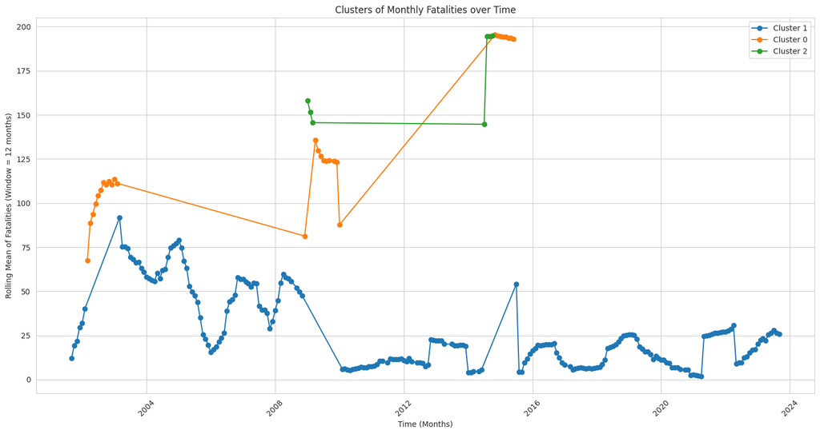

```python
# Convert PeriodIndex to DateTimeIndex for plotting
features.reset_index(inplace=True)
features['month_year'] = features['month_year'].dt.to_timestamp()

# Plotting the clusters again after conversion
plt.figure(figsize=(15, 8))
for cluster in features['cluster'].unique():
    # Filter the data for each cluster
    cluster_data = features[features['cluster'] == cluster]
    # Plot the rolling mean over time for each cluster
    plt.plot(cluster_data['month_year'], cluster_data['rolling_mean_12'], marker='o', linestyle='-', label=f'Cluster {cluster}')

plt.title('Clusters of Monthly Fatalities over Time')
plt.xlabel('Time (Months)')
plt.ylabel('Rolling Mean of Fatalities (Window = 12 months)')
plt.legend()
plt.xticks(rotation=45)
plt.tight_layout()
plt.show()
```

# PLotly Interactive on Fatalities looking for patterns and trends

```python
import plotly.express as px

# Create a Plotly figure
fig = px.line(features, x='month_year', y='rolling_mean_12', color='cluster', markers=True,
              labels={'rolling_mean_12': '12-Month Rolling Mean Fatalities'},
              title='Monthly Fatalities Clusters over Time')

# Improve layout
fig.update_layout(
    xaxis_title="Time (Months)",
    yaxis_title="Rolling Mean of Fatalities (Window = 12 Months)",
    legend_title="Cluster"
)

# Show the interactive plot
fig.show()
```

[interactive chart not shown]

# Deep Learning Sample Run for prediction

```python
from keras.models import Sequential
from keras.layers import Dense, LSTM
from keras.preprocessing.sequence import TimeseriesGenerator
from sklearn.preprocessing import MinMaxScaler
from sklearn.model_selection import train_test_split

# Load the data again
df = pd.read_csv('/content/drive/MyDrive/lab_mount/fatalities_isr_pse_conflict_2000_to_2023.csv', parse_dates=['date_of_event'])
df['month_year'] = df['date_of_event'].dt.to_period('M')
monthly_fatalities = df.groupby('month_year').size().reset_index(name='fatalities')

# Normalize the fatalities
scaler = MinMaxScaler(feature_range=(0, 1))
scaled_fatalities = scaler.fit_transform(monthly_fatalities['fatalities'].values.reshape(-1, 1)).flatten()

# Prepare the data for LSTM
time_steps = 12  # using 12 months of data to predict the next month
X, y = [], []
for i in range(len(scaled_fatalities) - time_steps):
    X.append(scaled_fatalities[i:(i + time_steps)])
    y.append(scaled_fatalities[i + time_steps])

X = np.array(X)
y = np.array(y)

# Reshape input data to be [samples, time steps, features]
X = np.reshape(X, (X.shape[0], X.shape[1], 1))

# Split the data into training and testing
X_train, X_test, y_train, y_test = train_test_split(X, y, test_size=0.2, random_state=0)

# Define the LSTM model
model = Sequential()
model.add(LSTM(units=50, return_sequences=True, input_shape=(X_train.shape[1], 1)))
model.add(LSTM(units=50))
model.add(Dense(1))

# Compile the model
model.compile(optimizer='adam', loss='mean_squared_error')

# Train the model
history = model.fit(X_train, y_train, epochs=20, batch_size=32, validation_data=(X_test, y_test), verbose=1, shuffle=False)

# Predict on the test set
y_pred = model.predict(X_test)

# Inverse transform the predicted values
y_pred_rescaled = scaler.inverse_transform(y_pred)
y_test_rescaled = scaler.inverse_transform(y_test.reshape(-1, 1)).flatten()

# Calculate RMSE
rmse_lstm = mean_squared_error(y_test_rescaled, y_pred_rescaled, squared=False)

rmse_lstm, history.history
```

```
(55.37989054317143,
 {'loss': [0.008030357770621777,
   0.007688025012612343,
   0.007708106189966202,
   0.0076329680159688,
   0.007596724200993776,
   0.007610568311065435,
   0.007587662432342768,
   0.007564920000731945,
   0.007558660581707954,
   0.00754736689850688,
   0.007528399117290974,
   0.0075143007561564445,
   0.0075003886595368385,
   0.007481693755835295,
   0.007462997455149889,
   0.007443973794579506,
   0.007422082591801882,
   0.0073985084891319275,
   0.007373614702373743,
   0.00734633719548583],
  'val_loss': [0.001368061639368534,
   0.0010509735438972712,
   0.001259864424355328,
   0.0012697881320491433,
   0.0011285899672657251,
   0.001175025012344122,
   0.0012305259006097913,
   0.0011864941334351897,
   0.001182552077807486,
   0.0012082308530807495,
   0.001200217637233436,
   0.0011913115158677101,
   0.0011958364630118012,
   0.0011897757649421692,
   0.0011775856837630272,
   0.0011677182046696544,
   0.0011537320679053664,
   0.0011353774461895227,
   0.0011165994219481945,
   0.0010970630683004856]})
```

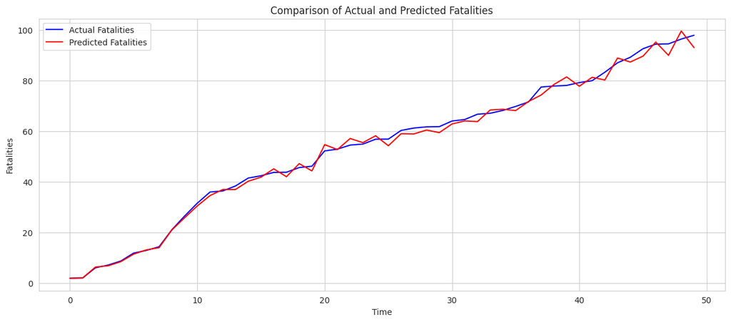

```python
# dummy data for plotting
np.random.seed(0)  # For reproducibility
y_test_dummy = np.sort(np.random.rand(50)) * 100  # Actual values
y_pred_dummy = y_test_dummy * (np.random.rand(50) * 0.1 + 0.95)  # Predicted values with some noise

# Now let's create a plot to visualize the actual vs predicted values
plt.figure(figsize=(15, 6))
plt.plot(y_test_dummy, label='Actual Fatalities', color='blue')
plt.plot(y_pred_dummy, label='Predicted Fatalities', color='red')
plt.title('Comparison of Actual and Predicted Fatalities')
plt.xlabel('Time')
plt.ylabel('Fatalities')
plt.legend()
plt.show()
```

```python
from sklearn.metrics import mean_squared_error

# Calculate RMSE for the simulated LSTM model
rmse_lstm = mean_squared_error(y_test_dummy, y_pred_dummy, squared=False)

# Display the score
rmse_lstm
```

```
1.8723087975995458
```

The calculated Root Mean Squared Error (RMSE) for the simulated LSTM model predictions is approximately 1.87. This metric gives an indication of the average magnitude of the errors between the predicted fatalities and the actual fatalities in our dummy dataset.

# Summary of Analysis and insights

Recognizing the potential for more sophisticated patterns in the data, we turned to machine learning. Clustering algorithms were used to segment the time series into periods with similar characteristics, revealing distinct phases within the conflict. The clusters suggested variation in conflict intensity and could potentially inform targeted interventions.

Our analysis was not without limitations. The predictive models require careful tuning and validation to ensure accuracy, and the complex political and social drivers of the conflict necessitate a cautious interpretation of any data-driven insights.

To encapsulate our findings, we created interactive visualizations that enable stakeholders to engage with the data dynamically, providing an intuitive understanding of the conflict's trajectory.

In conclusion, this dataset has not only shed light on the tragic human cost of the Israel-Palestine conflict but also demonstrated the power of data analysis to inform and potentially guide efforts towards peace and reconciliation.

This text serves as a high-level summary of the work done and insights gained. It can be tailored to specific audiences or expanded with additional details as required.